# PAM Booster: CISO User Guide

Radiant Logic

# General Concepts

## Introduction

PAM Booster allows the mapping and monitoring of the evolution of risks related to privileged accounts. Based on a snapshot of the CyberArk PAM and/or CyberArk Privilege Cloud configuration, including HR data and Active Directory or LDAP, PAM Booster creates a 360-degree view of identities and assets accessed through privileged accounts.

When looking at a privileged account, the access chain is reconstructed so that it is possible to understand who is using it, including the necessary context to determine the relevance of these authorizations as well as to understand to which asset in the company this privileged account corresponds. In the example of a database server privileged account, PAM Booster can track:

- the department to which the person who owns the account belongs, his or her job, whether the person is a service provider, etc., as well as
- the business applications and processes of the company indirectly impacted by this account.

The service provides checks on privileged accounts, the CyberArk configuration as well as access in relation to the security policy. Remediation advice is given and may target the privileged accounts, CyberArk access configuration or the structure of Active Directory.

All these elements are part of a concept known as “Get Clean” which aims to reduce the risks identified through controls. Secondly, since the company’s activities (organization, business, etc.) as well as its applications are likely to change, CyberArk accesses must be constantly monitored and re-evaluated to “Stay Clean.”

To do this, deviations are monitored over time by using trends based on snapshots taken of the HR, CyberArk and Active Directory environments. This helps verify that the situation is improving and remains under control.

## Structure of the Service

The service is structured around a home page, or dashboard, from which it is possible to access all its elements and expose the risks related to privileged accounts.

The general principle is to start with a general overview of KPIs and drill down to the details. Starting from a KPI, for example, it is possible to click on a number to go to the corresponding list and then to click on an item in the list to obtain its details.

A menu is also available on the left side of the page to access the search functions of certain elements (accounts, identities, applications, etc.).

# Privileged Account Risk and Methodology

The service is designed to provide an overview of the identified risks concerning privileged accounts managed in CyberArk.

## Types of Risk

The risks identified within the service can be classified into two main types:

- risks related to access security, and
- risks related to the quality of access to CyberArk.

Security risks address accesses to CyberArk and privileged accounts that are managed in CyberArk. Even when all privileged accounts are managed in CyberArk, there may be a configuration risk. Typically, if password rotation is not enabled, the password can be shared, making it possible to bypass CyberArk for access to a resource.

Nevertheless, individuals must be able to administer the CyberArk configuration. This puts CyberArk in the same position as any other resource:

- Some accounts are considered users within CyberArk and can access confidential credentials to reach other systems.
- Some accounts are considered administrators within CyberArk and can modify the configuration, backup, restore, etc.

Accesses must be carefully monitored because the risk is concentrated in a single place. The risks are various in nature:

- Segregation of duties: the same person should not be able to backup and restore, and the same person should not be able to use a confidential credential and administer the safe that contains it.
- Access relevance: a person who has changed functions but retains administrator access to a safe or a person who has left the company but who retains access to the confidential credentials of a safe are both considered as risks.

## Structure Suggestions

The risks are part of a control plan within the tool. Each control has, among other things, a description of the risk, a risk level, and the suggested remediation. The risk level varies from 1 to 4, with 1 being the lowest risk and 4 the highest risk.

In addition to the level of risk, a hierarchy is necessary when referring to privileged accounts. This is due to the possible lack of visibility on privileged accounts that have not yet been identified or those that have been identified but whose scope and impact on the company’s applications and assets is unknown.

RadiantOne Identity Analytics provides a simple security risk hierarchy in two main categories which can be found on the tool’s dashboard:

- Risks of accessing CyberArk without password rotation. The first issue is an account without password rotation which carries the same risks as an account that is not managed by CyberArk. This is because it is still possible to bypass CyberArk to access the resource.
- Risks related to accesses violating the security policy. This is the second type of problem and includes issues around segregation of duties.

Additionally, it may make sense to look at the characteristics of the individuals who have access to privileged accounts. The Identity Analytics tool provides separate rules and KPIs on what contractors can do because it is important to track the IT resources that are being accessed (including CyberArk) by third parties.

RadiantOne Identity Analytics also offers quality controls to maintain the CyberArk and Active Directory configurations.

## Methodological Elements

Regarding the prioritization proposed in the previous chapter, the following methodological elements emerge.

- The first issue is to understand the impact of privileged accounts. The Identity Analytics tool allows the access chain between identities, accounts, safes, accessed resources and organizations to be reconstructed.
- Another thing to consider is the monitoring of deviations from the security policy. When possible, password rotation should be in place. It is also important to uncover situations where the segregation of duties is not being followed.

The methodology is part of the principle of continuous improvement so that the situation does not drift after the initial efforts to reduce risk. CyberArk projects are constantly changing, mostly due to new business applications, organizational changes and changes in the IT infrastructure or services being used.

# Dashboard

The dashboard provides KPIs that show information related to CyberArk access and configuration.

KPIs are displayed in rectangles called “tiles” that show KPIs and trends on privileged account risk.

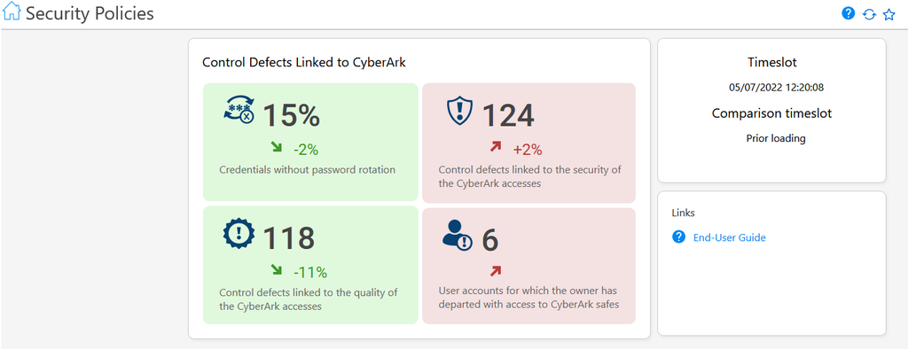

The background color of the tiles reflects the trend of the situation observed during the comparison analysis period displayed on the right.  
- Green for improvement,  
- Red for deterioration, and  
- Blue for a stable situation.

The tiles show the configuration risks within CyberArk and focus on confidential credentials where password rotation (CPM) is disabled.

On all tiles, it is possible to click on the KPI or percentage for details. The following chapters describe each tile.

## Risks Related to Privileged Accounts Managed by CyberArk

The panel shows KPIs for accounts managed by CyberArk. Pay special attention to the first tile which is the most important because it contains the number of credentials for which password rotation (CPM) is disabled.

- **Credentials without password rotation.** Password rotation should be enabled whenever possible to ensure the maximum security and confidentiality of credentials. When this is not possible, there must be an associated justification. This KPI displays the percentage of credentials without password rotation and without justification, that are not members of a safe with CPM disabled.
- **Control defects linked to the security of the CyberArk accesses.** This KPI is the number of security policy errors of users with access to CyberArk.  
  Only errors with a high or very high level of risk are considered in this KPI (risk level 3 and 4).  
  They relate to users of vaults and safes with access to credentials or with administrative or maintenance rights to the CyberArk configuration.  
  It is important to correct these errors to limit security risks and to comply with the security policy.
- **Control defects linked to the quality of the CyberArk accesses.** This KPI presents the number of errors related to the quality policy of the access to CyberArk.  
  These errors concern the users of vaults and safes who have access to confidential credentials or who have administration or maintenance rights on the CyberArk configuration.  
  It is important to correct these errors to improve the maintenance and optimization of the CyberArk configuration.
- **Accounts for which the owner has departed with access to CyberArk safes.** This KPI presents the number of user accounts having access to at least one CyberArk safe and owned by an identity having left the company.

# Control Details

## Control Results

Control results can be accessed in two ways:

- from the dashboard, and
- from the menu on the left.

The left menu is opened by clicking on the arrow at the top left of the page. When pressed, the menu opens or closes with regards to its previous state.

- Security Controls for Privileged Accounts Managed by CyberArk, and
- CyberArk Access and Configuration Quality Controls.

#### Detail of a control result.

Clicking on the arrow to the right of the number of a control result displays a details page. This page shows the list of accounts that correspond to the control results.

The page consists of two sections:

- the left side displays a list of accounts, and
- the right side displays the details when an account is selected in the left-hand list.

The details section includes four tabs:

- Accounts: details of the selected account,
- Groups: list of groups to which the account belongs,
- Safes: list of safes to which the account has access, and
- Vaults: list of vaults to which the account has access.

### Security Controls for Privileged Accounts Managed by CyberArk

The results page for security-related checks on privileged accounts with access to CyberArk looks like this:

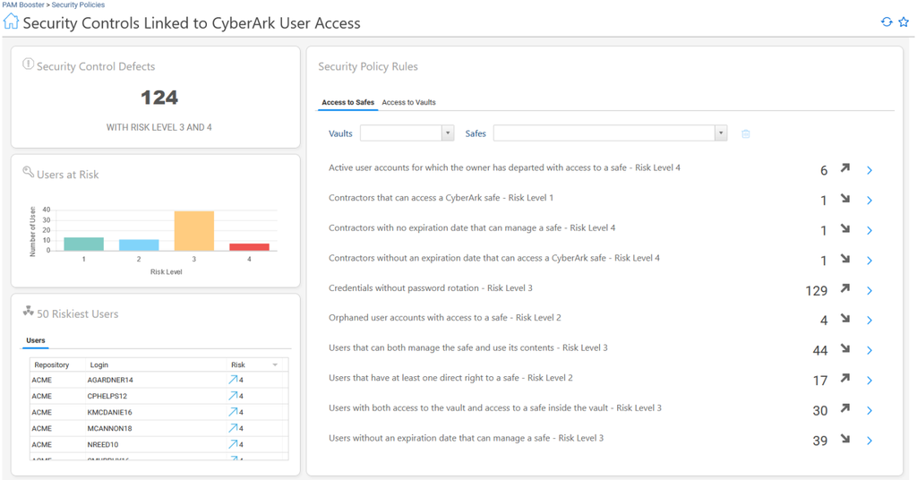

The page is broken down into three sections:

- a graph showing the accounts with access to CyberArk by risk level,
- the accounts with access to CyberArk that show a control error, sorted by level of risk, and
- the list of controls with the number of results for each.

The graph shows the distribution of accounts for the four levels of risk. Clicking on a risk level displays all the accounts with control errors that correspond to that selected risk level.

The list of accounts with access to CyberArk and sorted by risk level shows the account login and repository name. A risk level column gives the maximum risk related to this account.  
Keep in mind that an account can have issues on several control areas. The “Repository” and “Login” columns open a details box on the repository and the account respectively.

The list of controls is for accounts that have access to CyberArk. The number to the right of each control indicates the number of accounts with issues. An arrow indicates the trend (down, steady or up) with regards to the comparison analysis period. Further to the right is an arrow the links to the control details page.

### CyberArk Access and Configuration Quality Controls

- Safes: controls on accounts or groups that have access to a CyberArk safe.
- Vaults: controls for accounts or groups that have access to a CyberArk vault.

The Safes and Vaults tabs work in the same way. They display the account and group controls with a counter and an arrow to display the details for each control. A filter is available above the list of controls.

The details of a control are displayed in list form. If the selected control is about accounts, the list shows accounts. Likewise, it groups is selected, the list displays groups. Clicking on the account or group will jump to a details page about it.

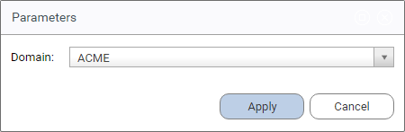

Once the repository is selected, the page displays the list of groups containing at least one account with access to CyberArk. The groups are both present in rows and columns and can be compared two by two.

A filter at the top of the page allows the scope of the analysis to be restricted by specifying the minimum number of accounts in the groups and the minimum similarity percentage. Initially, it is advisable to set these filters to a high enough value so that only the almost identical groups will be displayed. This will show whether a rationalization of the groups is possible. It is also a good idea to then lower the percentage of similarity to show groups that have similarities without having identical content.

# Trends

## Concept of the Analysis Period

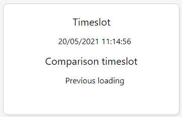

Note that the date displayed is the creation date of the data cube and not the extraction date from the different repositories.

## Principles of the Trend Calculation

The trend for each KPI or counter is calculated in relation to the comparison analysis period. The comparison analysis period makes it possible to compare the most recent data with a previous analysis period and then to calculate the differences and trends. Each time a data cube is loaded with new extractions from the systems, the old data remains present and accessible in the tool. In this way, changes to certain information such as counters, KPIs, risk indicators and object status (accounts, groups, identities, applications, etc.) can be displayed, indicating if the object is new or if it has been modified.

Interfaces within the tool show the evolution over time using arrows associated with the counters or KPIs. Typically, an upward arrow on an identity count indicates that there are more identities in the latest upload than there were in the comparison analysis period.

## Changing the Comparison Period

There is always a comparison analysis period. By default, the current timeslot is compared to the previous one named “Previous loading” in the interface. The previous timeslot used for comparison can be changed by the Identity Analytics administrator (role: “technicaladmin”). Please contact him if you need to change it.

# Conclusion

In summary, PAM Booster creates a 360-degree view of identities and assets accessed through privileged accounts and allows the mapping and monitoring of the evolution of risks related to these accounts.

The tool verifies privileged accounts and the CyberArk configuration and access with respect to the security policy. Because an organization’s activities often change, CyberArk accesses must be constantly monitored and re-evaluated to keep the level of on-going risk as low as possible. Using trends and KPIs, the goal is to keep privileged accounts clean and under control.

© 1995-2023 [Radiant Logic](https://developer.radiantlogic.com/)